# Artificial Neuron

## Components of Neural Networks

### Overview

The artificial neuron is the fundamental building block of neural networks. This component mimics the basic operation of biological neurons by computing a weighted sum of inputs, adding a bias term, and applying an activation function.

## Definition

A single artificial neuron implements the mathematical function:

$$ y = f(\mathbf{w}^T \mathbf{x} + b) $$

Where:

- $\mathbf{x}$ is the input vector
- $\mathbf{w}$ is the weight vector
- $b$ is the bias term
- $f$ is the activation function
- $y$ is the output

This component forms the basis for all neural network architectures.

## Mathematical Formulation

### Components

| **Symbol** | **Name** | **Description** |
| --- | --- | --- |
| $\mathbf{x}$ | Input vector | $[x_1, x_2, ..., x_n]$ |
| $\mathbf{w}$ | Weight vector | $[w_1, w_2, ..., w_n]$ |
| $b$ | Bias | Scalar offset |
| $z$ | Pre-activation | $\mathbf{w}^T \mathbf{x} + b$ |
| $f$ | Activation function | Non-linear transformation |
| **Output** | $y$ | Scalar output |

### Computation Steps

1. **Linear combination**: $z = \sum_{i=1}^{n} w_i x_i + b$
2. **Activation**: $y = f(z)$

### Common Activation Functions

The choice of activation function $f$ is crucial for the neuron's behavior. Here are some commonly used functions:

- **Sigmoid**: $f(z) = \frac{1}{1+e^{-z}}$
- **ReLU**: $f(z) = \max(0, z)$
- **Tanh**: $f(z) = \tanh(z)$

For a comprehensive study of activation functions, their properties, and implementations, see the Activation Functions notebook.

## Visual Representation

The following diagrams illustrate the structure and data flow of a single neuron:

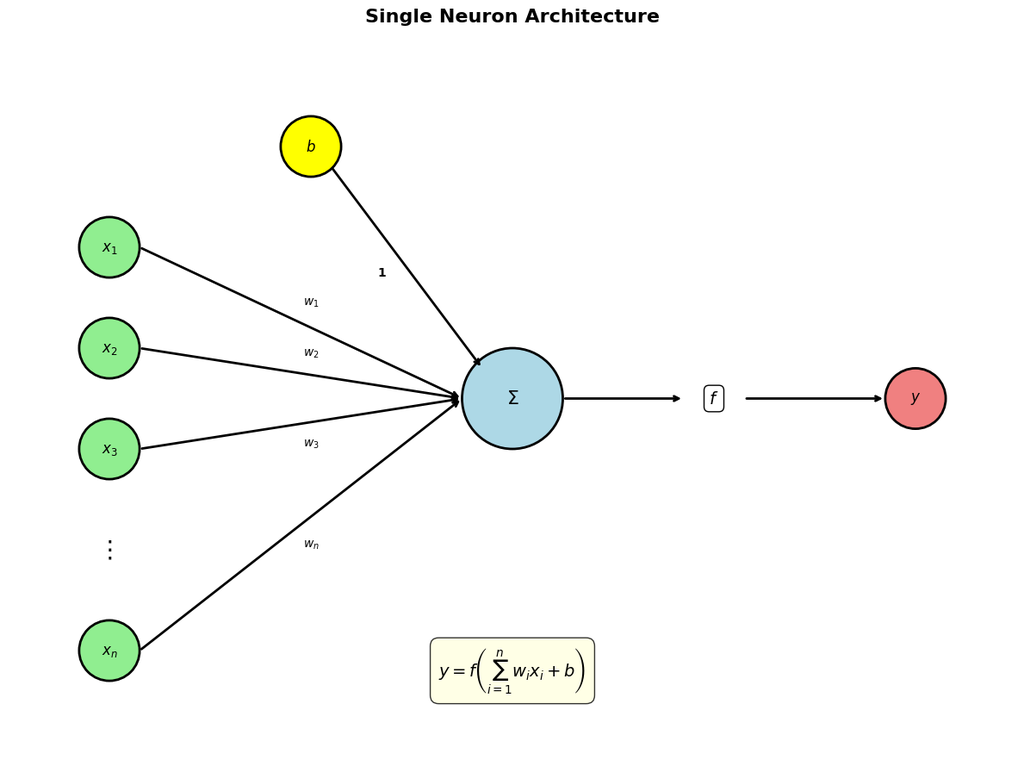

```python
import matplotlib.pyplot as plt
import matplotlib.patches as patches
import numpy as np

def draw_single_neuron():
    fig, ax = plt.subplots(1, 1, figsize=(12, 10))  # Increased height

    # Define positions
    input_x = -4
    input_ys = [3, 2, 1, -1]  # Skip 0 for dots
    bias_pos = (-2, 4)
    neuron_pos = (0, 1.5)
    output_pos = (4, 1.5)
    activation_pos = (2, 1.5)

    # Draw input nodes
    input_labels = ['$x_1$', '$x_2$', '$x_3$', '$x_n$']
    for i, (y, label) in enumerate(zip(input_ys, input_labels)):
        circle = patches.Circle((input_x, y), 0.3, facecolor='lightgreen',
                               edgecolor='black', linewidth=2)
        ax.add_patch(circle)
        ax.text(input_x, y, label, ha='center', va='center', fontsize=12, fontweight='bold')

    # Draw dots
    ax.text(input_x, 0, '⋮', ha='center', va='center', fontsize=20)

    # Draw bias node
    bias_circle = patches.Circle(bias_pos, 0.3, facecolor='yellow',
                                edgecolor='black', linewidth=2)
    ax.add_patch(bias_circle)
    ax.text(bias_pos[0], bias_pos[1], '$b$', ha='center', va='center',
            fontsize=12, fontweight='bold')

    # Draw neuron (summation)
    neuron_circle = patches.Circle(neuron_pos, 0.5, facecolor='lightblue',
                                  edgecolor='black', linewidth=2)
    ax.add_patch(neuron_circle)
    ax.text(neuron_pos[0], neuron_pos[1], '$\\Sigma$', ha='center', va='center',
            fontsize=16, fontweight='bold')

    # Draw activation function
    ax.text(activation_pos[0], activation_pos[1], '$f$', ha='center', va='center',
            fontsize=14, fontweight='bold',
            bbox=dict(boxstyle="round,pad=0.3", facecolor='white', edgecolor='black'))

    # Draw output node
    output_circle = patches.Circle(output_pos, 0.3, facecolor='lightcoral',
                                  edgecolor='black', linewidth=2)
    ax.add_patch(output_circle)
    ax.text(output_pos[0], output_pos[1], '$y$', ha='center', va='center',
            fontsize=12, fontweight='bold')

    # Draw arrows from inputs to neuron
    weight_labels = ['$w_1$', '$w_2$', '$w_3$', '$w_n$']
    for i, (y, w_label) in enumerate(zip(input_ys, weight_labels)):
        # Arrow
        ax.annotate('', xy=(neuron_pos[0]-0.5, neuron_pos[1]),
                   xytext=(input_x+0.3, y),
                   arrowprops=dict(arrowstyle='->', lw=2, color='black'))
        # Weight label
        mid_x = (input_x + neuron_pos[0]) / 2
        mid_y = (y + neuron_pos[1]) / 2
        offset_y = 0.2 if y > neuron_pos[1] else -0.2
        ax.text(mid_x, mid_y + offset_y, w_label, ha='center', va='center',
                fontsize=10, fontweight='bold')

    # Draw arrow from bias to neuron
    ax.annotate('', xy=(neuron_pos[0]-0.3, neuron_pos[1]+0.3),
               xytext=(bias_pos[0]+0.2, bias_pos[1]-0.2),
               arrowprops=dict(arrowstyle='->', lw=2, color='black'))
    ax.text((bias_pos[0] + neuron_pos[0])/2 - 0.3, (bias_pos[1] + neuron_pos[1])/2,
            '1', ha='center', va='center', fontsize=10, fontweight='bold')

    # Draw arrow from neuron to activation
    ax.annotate('', xy=(activation_pos[0]-0.3, activation_pos[1]),
               xytext=(neuron_pos[0]+0.5, neuron_pos[1]),
               arrowprops=dict(arrowstyle='->', lw=2, color='black'))

    # Draw arrow from activation to output
    ax.annotate('', xy=(output_pos[0]-0.3, output_pos[1]),
               xytext=(activation_pos[0]+0.3, activation_pos[1]),
               arrowprops=dict(arrowstyle='->', lw=2, color='black'))

    # Add mathematical expression at the bottom (moved higher to avoid cutting)
    ax.text(0, -1.2, r'$y = f\left(\sum_{i=1}^{n} w_i x_i + b\right)$',
            ha='center', va='center', fontsize=14, fontweight='bold',
            bbox=dict(boxstyle="round,pad=0.5", facecolor='lightyellow', alpha=0.8))

    # Set axis properties with more margin at bottom
    ax.set_xlim(-5, 5)
    ax.set_ylim(-2, 5)  # Extended bottom margin
    ax.set_aspect('equal')
    ax.axis('off')
    ax.set_title('Single Neuron Architecture', fontsize=16, fontweight='bold', pad=20)

    # Use subplots_adjust to ensure everything fits
    plt.subplots_adjust(bottom=0.1, top=0.9)
    plt.tight_layout()
    plt.show()

# Create the neuron diagram
draw_single_neuron()
```

```
\begin{tikzpicture}[
    node distance=2cm,
    neuron/.style={circle, draw, minimum size=1cm, fill=blue!20},
    input/.style={circle, draw, minimum size=0.8cm, fill=green!20},
    output/.style={circle, draw, minimum size=0.8cm, fill=red!20},
    bias/.style={circle, draw, minimum size=0.8cm, fill=yellow!20},
    arrow/.style={->, thick}
]

% Input nodes
\node[input] (x1) at (-3, 2) {$x_1$};
\node[input] (x2) at (-3, 1) {$x_2$};
\node[input] (x3) at (-3, 0) {$x_3$};
\node (dots) at (-3, -0.5) {$\vdots$};
\node[input] (xn) at (-3, -1) {$x_n$};

% Bias node
\node[bias] (b) at (-1, 3) {$b$};

% Neuron node
\node[neuron] (neuron) at (0, 0.5) {$\sum$};

% Output node
\node[output] (y) at (3, 0.5) {$y$};

% Activation function
\node at (1.5, 0.5) {$f$};

% Connections with weights
\draw[arrow] (x1) -- (neuron) node[midway, above] {$w_1$};
\draw[arrow] (x2) -- (neuron) node[midway, above] {$w_2$};
\draw[arrow] (x3) -- (neuron) node[midway, above] {$w_3$};
\draw[arrow] (xn) -- (neuron) node[midway, below] {$w_n$};
\draw[arrow] (b) -- (neuron) node[midway, left] {$1$};

% Output connection
\draw[arrow] (neuron) -- (y);

% Mathematical expression
\node at (0, -2.5) {$y = f\left(\sum_{i=1}^{n} w_i x_i + b\right)$};

\end{tikzpicture}
```

This diagram shows:

- **Input nodes** ($x_1, x_2, x_3, \ldots, x_n$): The input features
- **Weights** ($w_1, w_2, w_3, \ldots, w_n$): Parameters that scale each input
- **Bias** ($b$): Additional parameter added to the weighted sum
- **Summation** ($\sum$): The neuron computes the weighted sum of inputs plus bias
- **Activation function** ($f$): Applies non-linearity to the sum
- **Output** ($y$): The final result of the neuron

## PyTorch Implementation

Here's a simple implementation of the single neuron component using PyTorch:

```python
import torch
import torch.nn as nn

class SingleNeuron(nn.Module):
    """
    Implementation of a single artificial neuron.

    Computes: y = f(w^T * x + b)
    where f is the activation function (sigmoid in this case)
    """

    def __init__(self, input_dim):
        """
        Args:
            input_dim (int): Number of input features
        """
        super(SingleNeuron, self).__init__()
        # Linear layer: performs w^T * x + b
        self.linear = nn.Linear(input_dim, 1)

    def forward(self, x):
        """
        Forward pass through the neuron.

        Args:
            x (torch.Tensor): Input tensor of shape (batch_size, input_dim)

        Returns:
            torch.Tensor: Output tensor of shape (batch_size, 1)
        """
        # Step 1: Linear transformation (weighted sum + bias)
        z = self.linear(x)

        # Step 2: Apply activation function (sigmoid)
        y = torch.sigmoid(z)

        return y

# Example usage
if __name__ == '__main__':
    print("=== Single Neuron Component Demo ===")

    # Set random seed for reproducibility
    torch.manual_seed(42)

    # Create a neuron with 3 input features
    neuron = SingleNeuron(input_dim=3)

    # Display the neuron's parameters
    print(f"Weights: {neuron.linear.weight.data}")
    print(f"Bias: {neuron.linear.bias.data}")

    # Create sample input data (batch of 5 samples)
    X = torch.randn(5, 3)
    print(f"\nInput shape: {X.shape}")
    print(f"Input data:\n{X}")

    # Forward pass through the neuron
    outputs = neuron(X)
    print(f"\nOutput shape: {outputs.shape}")
    print(f"Outputs:\n{outputs}")

    # Show the computation step by step for the first sample
    print(f"\n=== Step-by-step computation for first sample ===")
    x_sample = X[0]  # First sample
    w = neuron.linear.weight.data.squeeze()  # Weights
    b = neuron.linear.bias.data.item()       # Bias

    # Manual computation
    z_manual = torch.dot(w, x_sample) + b
    y_manual = torch.sigmoid(z_manual)

    print(f"Input: {x_sample}")
    print(f"Weights: {w}")
    print(f"Bias: {b:.4f}")
    print(f"Linear combination (z): {z_manual:.4f}")
    print(f"After activation (y): {y_manual:.4f}")
    print(f"Network output: {outputs[0].item():.4f}")
    print(f"Match: {abs(y_manual - outputs[0].item()) < 1e-6}")
```

```
=== Single Neuron Component Demo ===
Weights: tensor([[ 0.4414,  0.4792, -0.1353]])
Bias: tensor([0.5304])

Input shape: torch.Size([5, 3])
Input data:
tensor([[ 0.2345,  0.2303, -1.1229],
        [-0.1863,  2.2082, -0.6380],
        [ 0.4617,  0.2674,  0.5349],
        [ 0.8094,  1.1103, -1.6898],
        [-0.9890,  0.9580,  1.3221]])

Output shape: torch.Size([5, 1])
Outputs:
tensor([[0.7101],
        [0.8310],
        [0.6878],
        [0.8387],
        [0.5924]], grad_fn=<SigmoidBackward0>)

=== Step-by-step computation for first sample ===
Input: tensor([ 0.2345,  0.2303, -1.1229])
Weights: tensor([ 0.4414,  0.4792, -0.1353])
Bias: 0.5304
Linear combination (z): 0.8961
After activation (y): 0.7101
Network output: 0.7101
Match: True
```

## Decision Boundary and Classification in 2D

### Mathematical Foundation

A single neuron can perform **binary classification** by learning a **decision boundary** that separates two classes in the input space. This is the core concept that generalizes to hyperplanes in higher dimensions.

#### Decision Boundary Equation

For a 2D input $\mathbf{x} = [x_1, x_2]^T$, the neuron computes:

$$z = w_1 x_1 + w_2 x_2 + b$$

The **decision boundary** is defined by the set of points where $z = 0$:

$$w_1 x_1 + w_2 x_2 + b = 0$$

This can be rearranged to the line equation:

$$x_2 = -\frac{w_1}{w_2} x_1 - \frac{b}{w_2}$$

#### Classification Rule

With sigmoid activation $\sigma(z) = \frac{1}{1+e^{-z}}$:

- **Class 1** (positive): $z > 0 \Rightarrow \sigma(z) > 0.5$
- **Class 0** (negative): $z < 0 \Rightarrow \sigma(z) < 0.5$
- **Decision boundary**: $z = 0 \Rightarrow \sigma(z) = 0.5$

#### Geometric Interpretation

- **Weight vector** $\mathbf{w} = [w_1, w_2]^T$ is **perpendicular** to the decision boundary
- **Bias** $b$ controls the **distance** of the line from the origin
- The neuron classifies points based on which **side** of the line they fall on

### Important Mathematical Clarifications

Before diving into decision boundaries, let's clarify the key mathematical distinctions:

#### Notation Convention

| Symbol | Name | Description | Example |
| --- | --- | --- | --- |
| $z$ | **Pre-activation** | Linear combination: $z = \mathbf{w}^T\mathbf{x} + b$ | $z = 2.5$ |
| $y$ | **Output** | After activation: $y = f(z)$ | $y = \sigma(2.5) = 0.924$ |
| $t$ | **Target/Label** | True value or class label | $t = 1$ (class) or $t = 3.7$ (regression) |

#### Two Main Tasks

**Classification Task:**

- **Activation**: Sigmoid $\sigma(z) = \frac{1}{1+e^{-z}}$
- **Decision rule**: $z > 0 \Rightarrow$ Class 1, $z < 0 \Rightarrow$ Class 0
- **Decision boundary**: $z = 0$ (equivalently $y = 0.5$)
- **Loss function**: Binary Cross-Entropy $L = -[t \log y + (1-t) \log(1-y)]$

**Regression Task:**

- **Activation**: Linear $f(z) = z$ (no activation)
- **Prediction**: $y = z = \mathbf{w}^T\mathbf{x} + b$
- **Loss function**: Mean Square Error $L = \frac{1}{2}(y - t)^2$

#### Why This Matters

The **decision boundary** is fundamentally about the **pre-activation** $z$:

- **Geometric boundary**: $z = \mathbf{w}^T\mathbf{x} + b = 0$
- **Classification threshold**: When $z = 0$, then $\sigma(z) = 0.5$
- **Weight vector interpretation**: $\mathbf{w}$ is perpendicular to the boundary $z = 0$

```
=== Mathematical Notation Demonstration ===

📊 REGRESSION TASK:
Input x: [1.0, 2.0, 3.0, 4.0]
Linear output y = z: [2.299999952316284, 4.099999904632568, 5.899999618530273, 7.699999809265137]
Target t: [2.0999999046325684, 3.9000000953674316, 6.199999809265137, 7.800000190734863]
MSE Loss: 0.0450
Formula: L = (1/2)*(y - t)²

🎯 CLASSIFICATION TASK:
Input x: [1.0, 2.0, 3.0, 4.0]
Pre-activation z: [-3.0, -1.0, 1.0, 3.0]
Output y = σ(z): [0.04742587357759476, 0.2689414322376251, 0.7310585975646973, 0.9525741338729858]
Target t: [0.0, 0.0, 1.0, 1.0]
BCE Loss: 0.1809
Formula: L = -[t*log(y) + (1-t)*log(1-y)]

🔍 DECISION BOUNDARY ANALYSIS:
Decision boundary occurs when z = 0
Current weight: 2.00
Current bias: -5.00
Boundary equation: 2.00*x + -5.00 = 0
Boundary at x = 2.50
At boundary: z = 0, y = σ(0) = 0.5
```

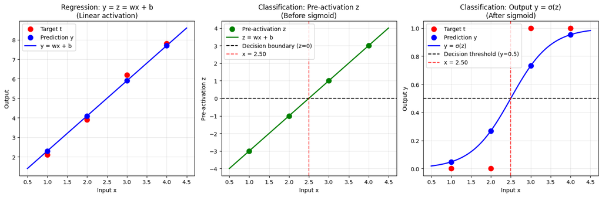

```
📚 KEY TAKEAWAYS:
1. z is the LINEAR combination (pre-activation)
2. y is the OUTPUT after activation function
3. Decision boundary is where z = 0 (equivalently y = 0.5 for sigmoid)
4. MSE for regression, BCE for classification
5. The geometric boundary equation uses z, not y
```

```python
# Mathematical demonstration: z vs y, MSE vs BCE
import torch
import torch.nn as nn
import matplotlib.pyplot as plt
import numpy as np

# Create sample data
torch.manual_seed(42)
x = torch.tensor([[1.0], [2.0], [3.0], [4.0]])  # Input
t_regression = torch.tensor([[2.1], [3.9], [6.2], [7.8]])  # Regression targets
t_classification = torch.tensor([[0.0], [0.0], [1.0], [1.0]])  # Classification targets

# Single neuron with different activations
class RegressionNeuron(nn.Module):
    def __init__(self):
        super().__init__()
        self.linear = nn.Linear(1, 1)

    def forward(self, x):
        z = self.linear(x)  # No activation for regression
        return z

class ClassificationNeuron(nn.Module):
    def __init__(self):
        super().__init__()
        self.linear = nn.Linear(1, 1)

    def forward(self, x):
        z = self.linear(x)
        y = torch.sigmoid(z)  # Sigmoid activation for classification
        return z, y  # Return both z and y for clarity

# Initialize neurons
reg_neuron = RegressionNeuron()
cls_neuron = ClassificationNeuron()

# Set some example weights for demonstration
with torch.no_grad():
    reg_neuron.linear.weight.fill_(1.8)
    reg_neuron.linear.bias.fill_(0.5)
    cls_neuron.linear.weight.fill_(2.0)
    cls_neuron.linear.bias.fill_(-5.0)

print("=== Mathematical Notation Demonstration ===\n")

# Regression example
print("📊 REGRESSION TASK:")
y_reg = reg_neuron(x)
mse_loss = nn.MSELoss()(y_reg, t_regression)
print(f"Input x: {x.squeeze().tolist()}")
print(f"Linear output y = z: {y_reg.squeeze().tolist()}")
print(f"Target t: {t_regression.squeeze().tolist()}")
print(f"MSE Loss: {mse_loss.item():.4f}")
print(f"Formula: L = (1/2)*(y - t)²\n")

# Classification example
print("🎯 CLASSIFICATION TASK:")
z_cls, y_cls = cls_neuron(x)
bce_loss = nn.BCELoss()(y_cls, t_classification)
print(f"Input x: {x.squeeze().tolist()}")
print(f"Pre-activation z: {z_cls.squeeze().tolist()}")
print(f"Output y = σ(z): {y_cls.squeeze().tolist()}")
print(f"Target t: {t_classification.squeeze().tolist()}")
print(f"BCE Loss: {bce_loss.item():.4f}")
print(f"Formula: L = -[t*log(y) + (1-t)*log(1-y)]")

# Decision boundary analysis
print(f"\n🔍 DECISION BOUNDARY ANALYSIS:")
print(f"Decision boundary occurs when z = 0")
print(f"Current weight: {cls_neuron.linear.weight.item():.2f}")
print(f"Current bias: {cls_neuron.linear.bias.item():.2f}")
print(f"Boundary equation: {cls_neuron.linear.weight.item():.2f}*x + {cls_neuron.linear.bias.item():.2f} = 0")
boundary_x = -cls_neuron.linear.bias.item() / cls_neuron.linear.weight.item()
print(f"Boundary at x = {boundary_x:.2f}")
print(f"At boundary: z = 0, y = σ(0) = 0.5")

# Visualization
fig, axes = plt.subplots(1, 3, figsize=(15, 5))

# Plot 1: Regression
ax1 = axes[0]
x_plot = np.linspace(0.5, 4.5, 100)
y_plot_reg = reg_neuron.linear.weight.item() * x_plot + reg_neuron.linear.bias.item()

ax1.scatter(x.numpy(), t_regression.numpy(), color='red', s=80, label='Target t', zorder=5)
ax1.scatter(x.numpy(), y_reg.detach().numpy(), color='blue', s=80, label='Prediction y', zorder=5)
ax1.plot(x_plot, y_plot_reg, 'blue', linewidth=2, label='y = wx + b')
ax1.set_xlabel('Input x')
ax1.set_ylabel('Output')
ax1.set_title('Regression: y = z = wx + b\n(Linear activation)')
ax1.legend()
ax1.grid(True, alpha=0.3)

# Plot 2: Classification - z values
ax2 = axes[1]
z_plot = cls_neuron.linear.weight.item() * x_plot + cls_neuron.linear.bias.item()
ax2.scatter(x.numpy(), z_cls.detach().numpy(), color='green', s=80, label='Pre-activation z', zorder=5)
ax2.plot(x_plot, z_plot, 'green', linewidth=2, label='z = wx + b')
ax2.axhline(y=0, color='black', linestyle='--', label='Decision boundary (z=0)')
ax2.axvline(x=boundary_x, color='red', linestyle='--', alpha=0.7, label=f'x = {boundary_x:.2f}')
ax2.set_xlabel('Input x')
ax2.set_ylabel('Pre-activation z')
ax2.set_title('Classification: Pre-activation z\n(Before sigmoid)')
ax2.legend()
ax2.grid(True, alpha=0.3)

# Plot 3: Classification - y values
ax3 = axes[2]
y_plot_cls = torch.sigmoid(torch.tensor(z_plot)).numpy()
ax3.scatter(x.numpy(), t_classification.numpy(), color='red', s=80, label='Target t', zorder=5)
ax3.scatter(x.numpy(), y_cls.detach().numpy(), color='blue', s=80, label='Prediction y', zorder=5)
ax3.plot(x_plot, y_plot_cls, 'blue', linewidth=2, label='y = σ(z)')
ax3.axhline(y=0.5, color='black', linestyle='--', label='Decision threshold (y=0.5)')
ax3.axvline(x=boundary_x, color='red', linestyle='--', alpha=0.7, label=f'x = {boundary_x:.2f}')
ax3.set_xlabel('Input x')
ax3.set_ylabel('Output y')
ax3.set_title('Classification: Output y = σ(z)\n(After sigmoid)')
ax3.legend()
ax3.grid(True, alpha=0.3)

plt.tight_layout()
plt.show()

print(f"\n📚 KEY TAKEAWAYS:")
print(f"1. z is the LINEAR combination (pre-activation)")
print(f"2. y is the OUTPUT after activation function")
print(f"3. Decision boundary is where z = 0 (equivalently y = 0.5 for sigmoid)")
print(f"4. MSE for regression, BCE for classification")
print(f"5. The geometric boundary equation uses z, not y")
```

### Visual Representation of Decision Boundary

The following diagrams illustrate how a single neuron creates a linear decision boundary in 2D space:

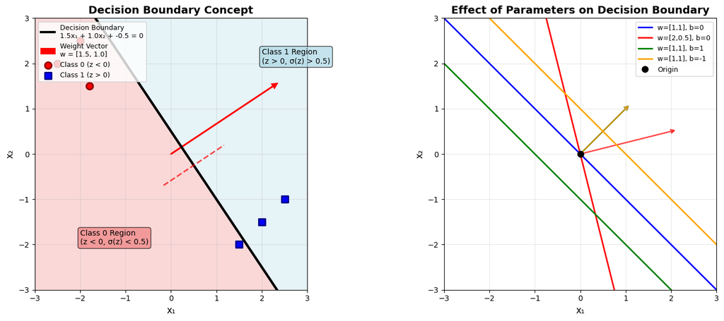

```
=== Decision Boundary Mathematics ===
General form: w₁x₁ + w₂x₂ + b = 0
Line form: x₂ = -(w₁/w₂)x₁ - (b/w₂)
Slope = -w₁/w₂
y-intercept = -b/w₂
Weight vector [w₁, w₂] is perpendicular to the boundary
Distance from origin = |b|/√(w₁² + w₂²)
```

```python
import matplotlib.pyplot as plt
import numpy as np
import matplotlib.patches as patches

def draw_decision_boundary_concept():
    """
    Draw a conceptual diagram showing decision boundary, weight vector, and classification regions.
    """
    fig, (ax1, ax2) = plt.subplots(1, 2, figsize=(15, 6))

    # === Left plot: Decision Boundary Concept ===
    ax1.set_title('Decision Boundary Concept', fontsize=14, fontweight='bold')

    # Define example parameters
    w1, w2, b = 1.5, 1.0, -0.5

    # Create decision boundary line
    x1_range = np.linspace(-3, 3, 100)
    x2_line = -(w1/w2) * x1_range - (b/w2)  # x2 = -(w1/w2)*x1 - (b/w2)

    # Plot decision boundary
    ax1.plot(x1_range, x2_line, 'k-', linewidth=3, label=f'Decision Boundary\n{w1:.1f}x₁ + {w2:.1f}x₂ + {b:.1f} = 0')

    # Add colored regions
    x1_mesh, x2_mesh = np.meshgrid(np.linspace(-3, 3, 50), np.linspace(-3, 3, 50))
    z_mesh = w1 * x1_mesh + w2 * x2_mesh + b

    # Color regions
    ax1.contourf(x1_mesh, x2_mesh, z_mesh, levels=[z_mesh.min(), 0, z_mesh.max()],
                colors=['lightcoral', 'lightblue'], alpha=0.3)
    ax1.contour(x1_mesh, x2_mesh, z_mesh, levels=[0], colors=['black'], linewidths=3)

    # Add weight vector (perpendicular to boundary)
    # Weight vector starts from origin
    weight_scale = 1.5
    ax1.arrow(0, 0, w1*weight_scale, w2*weight_scale, head_width=0.1, head_length=0.1,
             fc='red', ec='red', linewidth=2, label=f'Weight Vector\nw = [{w1:.1f}, {w2:.1f}]')

    # Add sample points
    # Class 0 points (negative side)
    class0_x1 = [-2.5, -1.8, -2.0]
    class0_x2 = [2.0, 1.5, 2.5]
    ax1.scatter(class0_x1, class0_x2, c='red', s=80, marker='o', edgecolors='darkred',
               linewidth=2, label='Class 0 (z < 0)', zorder=5)

    # Class 1 points (positive side)
    class1_x1 = [2.0, 1.5, 2.5]
    class1_x2 = [-1.5, -2.0, -1.0]
    ax1.scatter(class1_x1, class1_x2, c='blue', s=80, marker='s', edgecolors='darkblue',
               linewidth=2, label='Class 1 (z > 0)', zorder=5)

    # Add perpendicular line to show weight vector relationship
    # Find a point on the decision boundary
    x1_perp = 0.5
    x2_perp = -(w1/w2) * x1_perp - (b/w2)

    # Draw perpendicular line from boundary point
    perp_length = 0.8
    normal_x = w1 / np.sqrt(w1**2 + w2**2)
    normal_y = w2 / np.sqrt(w1**2 + w2**2)

    ax1.plot([x1_perp - perp_length*normal_x, x1_perp + perp_length*normal_x],
             [x2_perp - perp_length*normal_y, x2_perp + perp_length*normal_y],
             'r--', linewidth=2, alpha=0.7)

    # Add annotations
    ax1.text(-2, -2, 'Class 0 Region\n(z < 0, σ(z) < 0.5)', fontsize=10,
            bbox=dict(boxstyle="round,pad=0.3", facecolor='lightcoral', alpha=0.7))
    ax1.text(2, 2, 'Class 1 Region\n(z > 0, σ(z) > 0.5)', fontsize=10,
            bbox=dict(boxstyle="round,pad=0.3", facecolor='lightblue', alpha=0.7))

    ax1.set_xlim(-3, 3)
    ax1.set_ylim(-3, 3)
    ax1.set_xlabel('x₁', fontsize=12)
    ax1.set_ylabel('x₂', fontsize=12)
    ax1.grid(True, alpha=0.3)
    ax1.legend(loc='upper left', fontsize=9)
    ax1.set_aspect('equal')

    # === Right plot: Effect of Parameters ===
    ax2.set_title('Effect of Parameters on Decision Boundary', fontsize=14, fontweight='bold')

    # Show multiple decision boundaries with different parameters
    x1_range = np.linspace(-3, 3, 100)

    # Different weight combinations
    params = [
        (1.0, 1.0, 0, 'w=[1,1], b=0', 'blue'),
        (2.0, 0.5, 0, 'w=[2,0.5], b=0', 'red'),
        (1.0, 1.0, 1, 'w=[1,1], b=1', 'green'),
        (1.0, 1.0, -1, 'w=[1,1], b=-1', 'orange')
    ]

    for w1, w2, b, label, color in params:
        x2_line = -(w1/w2) * x1_range - (b/w2)
        ax2.plot(x1_range, x2_line, color=color, linewidth=2, label=label)

        # Add weight vector for each
        scale = 1.0
        ax2.arrow(0, 0, w1*scale, w2*scale, head_width=0.08, head_length=0.08,
                 fc=color, ec=color, alpha=0.7, linewidth=1.5)

    # Add origin point
    ax2.plot(0, 0, 'ko', markersize=8, label='Origin')

    ax2.set_xlim(-3, 3)
    ax2.set_ylim(-3, 3)
    ax2.set_xlabel('x₁', fontsize=12)
    ax2.set_ylabel('x₂', fontsize=12)
    ax2.grid(True, alpha=0.3)
    ax2.legend(loc='upper right', fontsize=9)
    ax2.set_aspect('equal')

    plt.tight_layout()
    plt.show()

    # Print mathematical relationships
    print("=== Decision Boundary Mathematics ===")
    print("General form: w₁x₁ + w₂x₂ + b = 0")
    print("Line form: x₂ = -(w₁/w₂)x₁ - (b/w₂)")
    print("Slope = -w₁/w₂")
    print("y-intercept = -b/w₂")
    print("Weight vector [w₁, w₂] is perpendicular to the boundary")
    print("Distance from origin = |b|/√(w₁² + w₂²)")

# Create the decision boundary visualization
draw_decision_boundary_concept()
```

### TikZ Version for LaTeX Documents

Here's the TikZ code to create publication-quality decision boundary diagrams:

```
\begin{tikzpicture}[scale=1.2]
    % Define styles
    \tikzstyle{class0} = [circle, fill=red!60, draw=red!80, minimum size=6pt, inner sep=0pt]
    \tikzstyle{class1} = [rectangle, fill=blue!60, draw=blue!80, minimum size=6pt, inner sep=0pt]
    \tikzstyle{boundary} = [thick, black]
    \tikzstyle{weight_vector} = [thick, red, -latex]
    \tikzstyle{region_label} = [font=\small]

    % Set up coordinate system
    \draw[->] (-3.5,0) -- (3.5,0) node[right] {$x_1$};
    \draw[->] (0,-3.5) -- (0,3.5) node[above] {$x_2$};

    % Grid
    \draw[help lines, opacity=0.3] (-3,-3) grid (3,3);

    % Decision boundary parameters: w1=1.5, w2=1.0, b=-0.5
    % Boundary equation: 1.5*x1 + 1.0*x2 - 0.5 = 0
    % Line form: x2 = -1.5*x1 + 0.5
    \def\wone{1.5}
    \def\wtwo{1.0}
    \def\bias{-0.5}

    % Draw decision boundary
    \draw[boundary] (-3, {-\wone/\wtwo*(-3) - \bias/\wtwo}) --
                    (3, {-\wone/\wtwo*(3) - \bias/\wtwo})
                    node[above right, font=\footnotesize] {$\wone x_1 + \wtwo x_2 + \bias = 0$};

    % Fill regions with different colors
    \fill[red!20, opacity=0.5] (-3,-3) -- (-3, {-\wone/\wtwo*(-3) - \bias/\wtwo}) --
                                (3, {-\wone/\wtwo*(3) - \bias/\wtwo}) -- (3,-3) -- cycle;
    \fill[blue!20, opacity=0.5] (-3,3) -- (-3, {-\wone/\wtwo*(-3) - \bias/\wtwo}) --
                                 (3, {-\wone/\wtwo*(3) - \bias/\wtwo}) -- (3,3) -- cycle;

    % Weight vector from origin
    \draw[weight_vector] (0,0) -- ({\wone*1.2}, {\wtwo*1.2})
          node[above right] {$\mathbf{w} = [\wone, \wtwo]$};

    % Sample data points
    % Class 0 (circles, red region)
    \node[class0] at (-2.5, 1.8) {};
    \node[class0] at (-1.8, 1.2) {};
    \node[class0] at (-2.0, 2.2) {};

    % Class 1 (squares, blue region)
    \node[class1] at (2.0, -1.8) {};
    \node[class1] at (1.5, -2.2) {};
    \node[class1] at (2.5, -1.2) {};

    % Region labels
    \node[region_label] at (-2, -2) {Class 0};
    \node[region_label] at (-2, -2.3) {$(z < 0)$};
    \node[region_label] at (2, 2) {Class 1};
    \node[region_label] at (2, 1.7) {$(z > 0)$};

    % Show perpendicular relationship
    \coordinate (P) at (0.5, {-\wone/\wtwo*(0.5) - \bias/\wtwo});
    \draw[dashed, red!60] (P) -- ++({\wtwo/sqrt(\wone*\wone + \wtwo*\wtwo)},
                                  {-\wone/sqrt(\wone*\wone + \wtwo*\wtwo)});
    \draw[dashed, red!60] (P) -- ++({-\wtwo/sqrt(\wone*\wone + \wtwo*\wtwo)},
                                  {\wone/sqrt(\wone*\wone + \wtwo*\wtwo)});

    % Mathematical annotations
    \node[below left] at (-3, -3) {
        \begin{tabular}{l}
            $z = w_1 x_1 + w_2 x_2 + b$ \\
            $\mathbf{w} \perp$ boundary \\
            $|b|/\|\mathbf{w}\|$ = distance to origin
        \end{tabular}
    };
\end{tikzpicture}
```

**Alternative TikZ for Parameter Effects:**

```
\begin{tikzpicture}[scale=0.8]
    % Multiple decision boundaries showing parameter effects
    \draw[->] (-4,0) -- (4,0) node[right] {$x_1$};
    \draw[->] (0,-4) -- (0,4) node[above] {$x_2$};
    \draw[help lines, opacity=0.2] (-3,-3) grid (3,3);

    % Different boundaries
    % w=[1,1], b=0 (blue)
    \draw[thick, blue] (-3,-3) -- (3,3) node[above right, blue] {$w=[1,1], b=0$};
    \draw[-latex, blue] (0,0) -- (1,1);

    % w=[2,0.5], b=0 (red)
    \draw[thick, red] (-3,-1.5) -- (3,1.5) node[above right, red] {$w=[2,0.5], b=0$};
    \draw[-latex, red] (0,0) -- (1.6,0.4);

    % w=[1,1], b=1 (green) - shifted up
    \draw[thick, green] (-4,-2) -- (2,4) node[above right, green] {$w=[1,1], b=1$};
    \draw[-latex, green] (0,0) -- (1,1);

    % w=[1,1], b=-1 (orange) - shifted down
    \draw[thick, orange] (-2,-4) -- (4,2) node[above right, orange] {$w=[1,1], b=-1$};
    \draw[-latex, orange] (0,0) -- (1,1);

    \node at (0,0) [circle, fill=black, inner sep=1pt] {};
    \node[below left] at (0,0) {Origin};
\end{tikzpicture}
```

**Key TikZ Components:**

- **Coordinate system**: Axes and grid for reference
- **Decision boundary**: Line defined by $w_1 x_1 + w_2 x_2 + b = 0$
- **Colored regions**: Visual separation of classes
- **Weight vector**: Arrow showing perpendicular direction
- **Sample points**: Different shapes for different classes
- **Mathematical annotations**: Key equations and relationships

### Gradient-Based Learning

The neuron learns by adjusting weights and bias using **gradient descent** to minimize the loss function.

#### Mathematical Notation Clarification

**Important distinction**:

- $z = \mathbf{w}^T\mathbf{x} + b$ (linear combination, pre-activation)
- $y = f(z) = \sigma(z)$ (output after activation function)

#### Loss Functions

**For Binary Classification** (with sigmoid activation):

Binary Cross-Entropy Loss with true label $t \in \{0, 1\}$ and prediction $y$:

$$L_{BCE} = -[t \log y + (1-t) \log(1-y)]$$

**For Regression** (with linear activation):

Mean Square Error Loss with true value $t$ and prediction $y$:

$$L_{MSE} = \frac{1}{2}(y - t)^2$$

#### Gradients for Both Loss Functions

Using chain rule: $\frac{\partial L}{\partial w_i} = \frac{\partial L}{\partial y} \cdot \frac{\partial y}{\partial z} \cdot \frac{\partial z}{\partial w_i}$

**For MSE Loss** (regression with linear activation $y = z$):

$$\frac{\partial L_{MSE}}{\partial w_i} = (y - t) \cdot x_i$$

$$\frac{\partial L_{MSE}}{\partial b} = (y - t)$$

**For BCE Loss** (classification with sigmoid activation $y = \sigma(z)$):

The BCE gradients are more complex before simplification:

$$\frac{\partial L_{BCE}}{\partial w_i} = \left[\frac{y - t}{y(1-y)}\right] \cdot y(1-y) \cdot x_i = (y - t) \cdot x_i$$

$$\frac{\partial L_{BCE}}{\partial b} = (y - t)$$

**Remarkable coincidence**: Both MSE and BCE with sigmoid give the **same gradient form**!

- **MSE**: Direct derivative of $\frac{1}{2}(y-t)^2$
- **BCE + Sigmoid**: The sigmoid derivative $\sigma'(z) = \sigma(z)(1-\sigma(z))$ perfectly cancels with BCE's derivative, yielding the same simple form

#### Parameter Updates

Using learning rate $\eta$:

$$w_i \leftarrow w_i - \eta \frac{\partial L}{\partial w_i}$$

$$b \leftarrow b - \eta \frac{\partial L}{\partial b}$$

The decision boundary **rotates** and **translates** during training to better separate the classes.

```python
# Demonstrate the gradient calculation for both MSE and BCE
import torch
import torch.nn as nn
import numpy as np

print("=== Gradient Calculation Demonstration ===\n")

# Sample data
x = torch.tensor([2.0], requires_grad=False)
t_reg = torch.tensor([3.5])  # Regression target
t_cls = torch.tensor([1.0])  # Classification target

# Parameters (with gradient tracking)
w = torch.tensor([1.5], requires_grad=True)
b = torch.tensor([0.5], requires_grad=True)

print("Sample input x =", x.item())
print("Regression target t =", t_reg.item())
print("Classification target t =", t_cls.item())
print("Initial weight w =", w.item())
print("Initial bias b =", b.item())

# === MSE Case (Regression) ===
print("\n🔢 MSE LOSS (Regression):")

# Forward pass (linear activation)
z_reg = w * x + b
y_reg = z_reg  # Linear activation: y = z
mse_loss = 0.5 * (y_reg - t_reg)**2

print(f"z = wx + b = {w.item():.2f} × {x.item():.2f} + {b.item():.2f} = {z_reg.item():.2f}")
print(f"y = z = {y_reg.item():.2f} (linear activation)")
print(f"MSE Loss = 0.5 × (y - t)² = 0.5 × ({y_reg.item():.2f} - {t_reg.item():.2f})² = {mse_loss.item():.4f}")

# Compute gradients
mse_loss.backward()
print(f"∂L/∂w = (y - t) × x = ({y_reg.item():.2f} - {t_reg.item():.2f}) × {x.item():.2f} = {w.grad.item():.2f}")
print(f"∂L/∂b = (y - t) = ({y_reg.item():.2f} - {t_reg.item():.2f}) = {b.grad.item():.2f}")

# Reset gradients
w.grad.zero_()
b.grad.zero_()

# === BCE Case (Classification) ===
print("\n🎯 BCE LOSS (Classification):")

# Forward pass (sigmoid activation)
z_cls = w * x + b
y_cls = torch.sigmoid(z_cls)  # Sigmoid activation
bce_loss = -(t_cls * torch.log(y_cls) + (1 - t_cls) * torch.log(1 - y_cls))

print(f"z = wx + b = {w.item():.2f} × {x.item():.2f} + {b.item():.2f} = {z_cls.item():.2f}")
print(f"y = σ(z) = σ({z_cls.item():.2f}) = {y_cls.item():.4f} (sigmoid activation)")
print(f"BCE Loss = -[t×log(y) + (1-t)×log(1-y)] = {bce_loss.item():.4f}")

# Compute gradients
bce_loss.backward()
print(f"∂L/∂w = (y - t) × x = ({y_cls.item():.4f} - {t_cls.item():.2f}) × {x.item():.2f} = {w.grad.item():.4f}")
print(f"∂L/∂b = (y - t) = ({y_cls.item():.4f} - {t_cls.item():.2f}) = {b.grad.item():.4f}")

# === Mathematical Explanation ===
print("\n📚 MATHEMATICAL BREAKDOWN:")
print("\nFor MSE (y = z, linear activation):")
print("L = ½(y - t)²")
print("∂L/∂y = (y - t)")
print("∂y/∂z = 1  (linear activation)")
print("∂L/∂w = ∂L/∂y × ∂y/∂z × ∂z/∂w = (y - t) × 1 × x = (y - t) × x")

print("\nFor BCE (y = σ(z), sigmoid activation):")
print("L = -[t×log(y) + (1-t)×log(1-y)]")
print("∂L/∂y = -(t/y - (1-t)/(1-y)) = (y - t)/(y(1-y))")
print("∂y/∂z = σ'(z) = σ(z)(1-σ(z)) = y(1-y)  (sigmoid derivative)")
print("∂L/∂w = ∂L/∂y × ∂y/∂z × ∂z/∂w = [(y-t)/(y(1-y))] × [y(1-y)] × x = (y - t) × x")

print("\n🎉 REMARKABLE RESULT:")
print("Both MSE and BCE+sigmoid give the SAME gradient formula: (y - t) × x")
print("This is why the gradient descent update looks identical for both cases!")

# Demonstrate the cancellation visually
print(f"\nNumerical verification:")
y_val = y_cls.item()
t_val = t_cls.item()
x_val = x.item()

# BCE gradient breakdown
bce_dy = (y_val - t_val) / (y_val * (1 - y_val))  # ∂L/∂y for BCE
sigmoid_dz = y_val * (1 - y_val)                  # ∂y/∂z for sigmoid
dz_dw = x_val                                     # ∂z/∂w

print(f"BCE: ∂L/∂y = (y-t)/(y(1-y)) = {bce_dy:.4f}")
print(f"Sigmoid: ∂y/∂z = y(1-y) = {sigmoid_dz:.4f}")
print(f"Chain rule: ∂L/∂w = {bce_dy:.4f} × {sigmoid_dz:.4f} × {dz_dw:.1f} = {bce_dy * sigmoid_dz * dz_dw:.4f}")
print(f"Direct: (y - t) × x = ({y_val:.4f} - {t_val:.1f}) × {x_val:.1f} = {(y_val - t_val) * x_val:.4f}")
print("✅ They match! The y(1-y) terms cancel perfectly.")
```

```
=== Gradient Calculation Demonstration ===

Sample input x = 2.0
Regression target t = 3.5
Classification target t = 1.0
Initial weight w = 1.5
Initial bias b = 0.5

🔢 MSE LOSS (Regression):
z = wx + b = 1.50 × 2.00 + 0.50 = 3.50
y = z = 3.50 (linear activation)
MSE Loss = 0.5 × (y - t)² = 0.5 × (3.50 - 3.50)² = 0.0000
∂L/∂w = (y - t) × x = (3.50 - 3.50) × 2.00 = 0.00
∂L/∂b = (y - t) = (3.50 - 3.50) = 0.00

🎯 BCE LOSS (Classification):
z = wx + b = 1.50 × 2.00 + 0.50 = 3.50
y = σ(z) = σ(3.50) = 0.9707 (sigmoid activation)
BCE Loss = -[t×log(y) + (1-t)×log(1-y)] = 0.0298
∂L/∂w = (y - t) × x = (0.9707 - 1.00) × 2.00 = -0.0586
∂L/∂b = (y - t) = (0.9707 - 1.00) = -0.0293

📚 MATHEMATICAL BREAKDOWN:

For MSE (y = z, linear activation):
L = ½(y - t)²
∂L/∂y = (y - t)
∂y/∂z = 1  (linear activation)
∂L/∂w = ∂L/∂y × ∂y/∂z × ∂z/∂w = (y - t) × 1 × x = (y - t) × x

For BCE (y = σ(z), sigmoid activation):
L = -[t×log(y) + (1-t)×log(1-y)]
∂L/∂y = -(t/y - (1-t)/(1-y)) = (y - t)/(y(1-y))
∂y/∂z = σ'(z) = σ(z)(1-σ(z)) = y(1-y)  (sigmoid derivative)
∂L/∂w = ∂L/∂y × ∂y/∂z × ∂z/∂w = [(y-t)/(y(1-y))] × [y(1-y)] × x = (y - t) × x

🎉 REMARKABLE RESULT:
Both MSE and BCE+sigmoid give the SAME gradient formula: (y - t) × x
This is why the gradient descent update looks identical for both cases!

Numerical verification:
BCE: ∂L/∂y = (y-t)/(y(1-y)) = -1.0302
Sigmoid: ∂y/∂z = y(1-y) = 0.0285
Chain rule: ∂L/∂w = -1.0302 × 0.0285 × 2.0 = -0.0586
Direct: (y - t) × x = (0.9707 - 1.0) × 2.0 = -0.0586
✅ They match! The y(1-y) terms cancel perfectly.
```

### Gradient Descent Algorithm Philosophy

The fundamental principle of **gradient descent** is to iteratively move in the direction opposite to the gradient to find the minimum of a loss function. This process can be visualized as a ball rolling down a hill, where:

- **The hill** represents the loss landscape
- **The ball's position** represents current parameter values
- **The slope** at any point is the gradient
- **Rolling downhill** means moving opposite to the gradient direction

#### Mathematical Foundation

Given a loss function $L(\mathbf{w}, b)$ where $\mathbf{w}$ are weights and $b$ is bias:

1. **Compute gradient**: $\nabla L = \left[\frac{\partial L}{\partial w_1}, \frac{\partial L}{\partial w_2}, \frac{\partial L}{\partial b}\right]^T$
2. **Update parameters**: $\mathbf{w}^{(t+1)} = \mathbf{w}^{(t)} - \eta \nabla_{\mathbf{w}} L$
3. **Repeat until convergence**: Continue until $|\nabla L| < \epsilon$ or maximum iterations reached

#### Key Concepts

- **Learning rate** $\eta$: Controls step size (too large → overshoot, too small → slow convergence)
- **Local minima**: Algorithm finds nearby minimum, not necessarily global minimum
- **Convergence**: Process stops when gradient approaches zero
- **Trajectory**: Path taken through parameter space during optimization

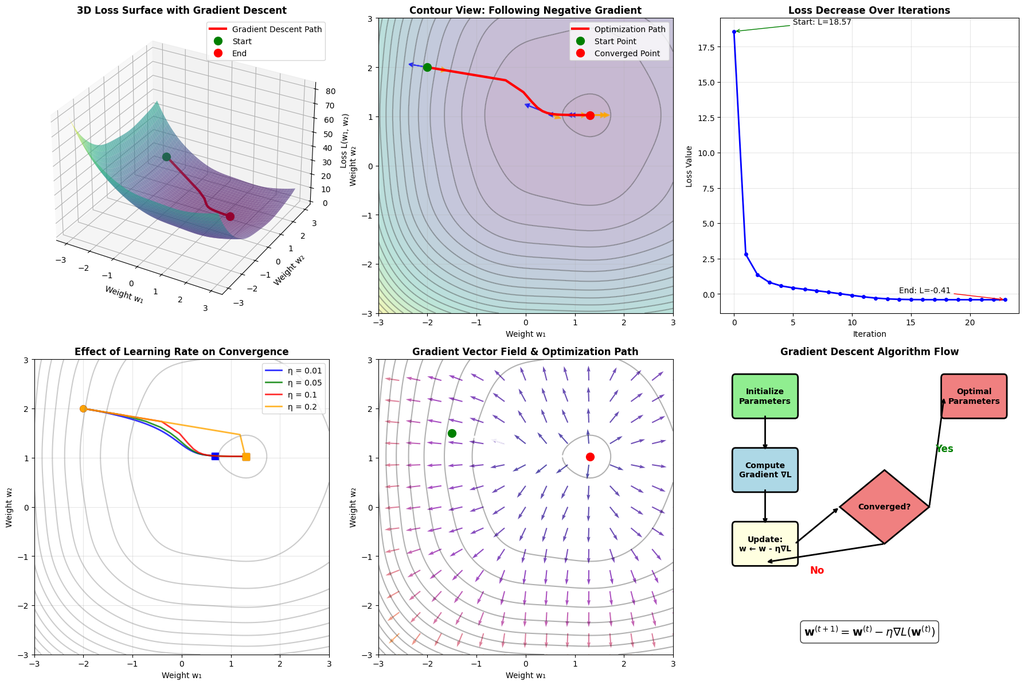

```
=== Gradient Descent Insights ===
Starting point: (-2.00, 2.00)
Final point: (1.31, 1.03)
Initial loss: 18.5719
Final loss: -0.4145
Loss reduction: 18.9863
Iterations to converge: 24
Average step size: 0.1555
```

```python
import numpy as np
import matplotlib.pyplot as plt
from mpl_toolkits.mplot3d import Axes3D
import matplotlib.patches as patches

def create_loss_surface():
    """Create a complex 2D loss function for visualization."""
    x = np.linspace(-3, 3, 100)
    y = np.linspace(-3, 3, 100)
    X, Y = np.meshgrid(x, y)

    # Complex loss surface with multiple local minima
    Z = (X**2 + Y**2 - 2*X - 2*Y + 2 +
         0.3*np.sin(3*X) + 0.3*np.cos(3*Y) +
         0.1*(X-1)**4 + 0.1*(Y-1)**4)

    return X, Y, Z

def gradient_2d(x, y):
    """Compute gradient of the loss function at point (x, y)."""
    # Analytical gradient of our loss function
    dx = 2*x - 2 + 0.9*np.cos(3*x) + 0.4*(x-1)**3
    dy = 2*y - 2 - 0.9*np.sin(3*y) + 0.4*(y-1)**3
    return dx, dy

def gradient_descent_trajectory(start_x, start_y, learning_rate=0.1, max_iter=50):
    """Simulate gradient descent trajectory."""
    trajectory = [(start_x, start_y)]
    x, y = start_x, start_y

    for i in range(max_iter):
        # Compute gradient
        dx, dy = gradient_2d(x, y)

        # Update parameters (move opposite to gradient)
        x = x - learning_rate * dx
        y = y - learning_rate * dy

        trajectory.append((x, y))

        # Stop if gradient is very small (convergence)
        if np.sqrt(dx**2 + dy**2) < 0.01:
            break

    return np.array(trajectory)

# Create comprehensive gradient descent visualization
fig = plt.figure(figsize=(18, 12))

# === Plot 1: 3D Loss Surface with Trajectory ===
ax1 = fig.add_subplot(2, 3, 1, projection='3d')
X, Y, Z = create_loss_surface()

# Plot surface
surf = ax1.plot_surface(X, Y, Z, cmap='viridis', alpha=0.6, linewidth=0, antialiased=True)

# Add gradient descent trajectory
start_point = (-2, 2)
trajectory = gradient_descent_trajectory(start_point[0], start_point[1], learning_rate=0.1)

# Compute loss values along trajectory
traj_z = []
for tx, ty in trajectory:
    tz = (tx**2 + ty**2 - 2*tx - 2*ty + 2 +
          0.3*np.sin(3*tx) + 0.3*np.cos(3*ty) +
          0.1*(tx-1)**4 + 0.1*(ty-1)**4)
    traj_z.append(tz)

# Plot trajectory
ax1.plot(trajectory[:, 0], trajectory[:, 1], traj_z, 'r-', linewidth=3, label='Gradient Descent Path')
ax1.plot([trajectory[0, 0]], [trajectory[0, 1]], [traj_z[0]], 'go', markersize=10, label='Start')
ax1.plot([trajectory[-1, 0]], [trajectory[-1, 1]], [traj_z[-1]], 'ro', markersize=10, label='End')

ax1.set_title('3D Loss Surface with Gradient Descent', fontsize=12, fontweight='bold')
ax1.set_xlabel('Weight w₁')
ax1.set_ylabel('Weight w₂')
ax1.set_zlabel('Loss L(w₁, w₂)')
ax1.legend()

# === Plot 2: 2D Contour with Trajectory ===
ax2 = fig.add_subplot(2, 3, 2)
contour = ax2.contour(X, Y, Z, levels=20, colors='gray', alpha=0.6)
ax2.contourf(X, Y, Z, levels=20, cmap='viridis', alpha=0.3)

# Plot trajectory
ax2.plot(trajectory[:, 0], trajectory[:, 1], 'r-', linewidth=3, label='Optimization Path')
ax2.plot(trajectory[0, 0], trajectory[0, 1], 'go', markersize=10, label='Start Point')
ax2.plot(trajectory[-1, 0], trajectory[-1, 1], 'ro', markersize=10, label='Converged Point')

# Add gradient arrows at several points
for i in range(0, len(trajectory)-1, 5):
    x, y = trajectory[i]
    dx, dy = gradient_2d(x, y)
    # Normalize for visualization
    norm = np.sqrt(dx**2 + dy**2)
    if norm > 0:
        dx, dy = dx/norm * 0.3, dy/norm * 0.3
        # Gradient arrow (pointing uphill)
        ax2.arrow(x, y, dx, dy, head_width=0.08, head_length=0.08,
                 fc='blue', ec='blue', alpha=0.7, linewidth=1.5)
        # Step arrow (pointing downhill, opposite to gradient)
        ax2.arrow(x, y, -dx, -dy, head_width=0.08, head_length=0.08,
                 fc='orange', ec='orange', alpha=0.8, linewidth=2)

ax2.set_title('Contour View: Following Negative Gradient', fontsize=12, fontweight='bold')
ax2.set_xlabel('Weight w₁')
ax2.set_ylabel('Weight w₂')
ax2.legend()
ax2.grid(True, alpha=0.3)
ax2.set_aspect('equal')

# === Plot 3: Loss vs Iteration ===
ax3 = fig.add_subplot(2, 3, 3)
iterations = range(len(traj_z))
ax3.plot(iterations, traj_z, 'b-', linewidth=2, marker='o', markersize=4)
ax3.set_title('Loss Decrease Over Iterations', fontsize=12, fontweight='bold')
ax3.set_xlabel('Iteration')
ax3.set_ylabel('Loss Value')
ax3.grid(True, alpha=0.3)

# Annotate key points
ax3.annotate(f'Start: L={traj_z[0]:.2f}', xy=(0, traj_z[0]), xytext=(5, traj_z[0]+0.5),
            arrowprops=dict(arrowstyle='->', color='green'), fontsize=10)
ax3.annotate(f'End: L={traj_z[-1]:.2f}', xy=(len(traj_z)-1, traj_z[-1]),
            xytext=(len(traj_z)-10, traj_z[-1]+0.5),
            arrowprops=dict(arrowstyle='->', color='red'), fontsize=10)

# === Plot 4: Different Learning Rates Comparison ===
ax4 = fig.add_subplot(2, 3, 4)
learning_rates = [0.01, 0.05, 0.1, 0.2]
colors = ['blue', 'green', 'red', 'orange']

for lr, color in zip(learning_rates, colors):
    traj = gradient_descent_trajectory(-2, 2, learning_rate=lr, max_iter=100)
    ax4.plot(traj[:, 0], traj[:, 1], color=color, linewidth=2,
            label=f'η = {lr}', alpha=0.8)
    ax4.plot(traj[0, 0], traj[0, 1], 'o', color=color, markersize=8)
    ax4.plot(traj[-1, 0], traj[-1, 1], 's', color=color, markersize=8)

# Add contour background
ax4.contour(X, Y, Z, levels=15, colors='gray', alpha=0.4)
ax4.set_title('Effect of Learning Rate on Convergence', fontsize=12, fontweight='bold')
ax4.set_xlabel('Weight w₁')
ax4.set_ylabel('Weight w₂')
ax4.legend()
ax4.grid(True, alpha=0.3)
ax4.set_aspect('equal')

# === Plot 5: Gradient Vector Field ===
ax5 = fig.add_subplot(2, 3, 5)
# Create a coarser grid for vector field
x_vec = np.linspace(-3, 3, 15)
y_vec = np.linspace(-3, 3, 15)
X_vec, Y_vec = np.meshgrid(x_vec, y_vec)

# Compute gradients at each point
DX = np.zeros_like(X_vec)
DY = np.zeros_like(Y_vec)
for i in range(X_vec.shape[0]):
    for j in range(X_vec.shape[1]):
        dx, dy = gradient_2d(X_vec[i, j], Y_vec[i, j])
        DX[i, j] = dx
        DY[i, j] = dy

# Normalize vectors for better visualization
norm = np.sqrt(DX**2 + DY**2)
DX_norm = DX / (norm + 1e-8)
DY_norm = DY / (norm + 1e-8)

# Plot vector field (gradient directions)
ax5.quiver(X_vec, Y_vec, DX_norm, DY_norm, norm, cmap='plasma', alpha=0.7, scale=20)
ax5.contour(X, Y, Z, levels=15, colors='black', alpha=0.3)

# Add sample trajectory
sample_traj = gradient_descent_trajectory(-1.5, 1.5, learning_rate=0.08)
ax5.plot(sample_traj[:, 0], sample_traj[:, 1], 'white', linewidth=3, alpha=0.9)
ax5.plot(sample_traj[0, 0], sample_traj[0, 1], 'go', markersize=10)
ax5.plot(sample_traj[-1, 0], sample_traj[-1, 1], 'ro', markersize=10)

ax5.set_title('Gradient Vector Field & Optimization Path', fontsize=12, fontweight='bold')
ax5.set_xlabel('Weight w₁')
ax5.set_ylabel('Weight w₂')
ax5.set_aspect('equal')

# === Plot 6: Algorithm Conceptual Diagram ===
ax6 = fig.add_subplot(2, 3, 6)
ax6.set_xlim(0, 10)
ax6.set_ylim(0, 8)

# Draw algorithm flowchart
# Start
start_box = patches.FancyBboxPatch((0.5, 6.5), 2, 1, boxstyle="round,pad=0.1",
                                  facecolor='lightgreen', edgecolor='black', linewidth=2)
ax6.add_patch(start_box)
ax6.text(1.5, 7, 'Initialize\nParameters', ha='center', va='center', fontweight='bold')

# Compute gradient
grad_box = patches.FancyBboxPatch((0.5, 4.5), 2, 1, boxstyle="round,pad=0.1",
                                 facecolor='lightblue', edgecolor='black', linewidth=2)
ax6.add_patch(grad_box)
ax6.text(1.5, 5, 'Compute\nGradient ∇L', ha='center', va='center', fontweight='bold')

# Update parameters
update_box = patches.FancyBboxPatch((0.5, 2.5), 2, 1, boxstyle="round,pad=0.1",
                                   facecolor='lightyellow', edgecolor='black', linewidth=2)
ax6.add_patch(update_box)
ax6.text(1.5, 3, 'Update:\nw ← w - η∇L', ha='center', va='center', fontweight='bold')

# Decision diamond
decision_points = np.array([[4, 4], [5.5, 5], [7, 4], [5.5, 3]])
decision = patches.Polygon(decision_points, facecolor='lightcoral', edgecolor='black', linewidth=2)
ax6.add_patch(decision)
ax6.text(5.5, 4, 'Converged?', ha='center', va='center', fontweight='bold')

# End
end_box = patches.FancyBboxPatch((7.5, 6.5), 2, 1, boxstyle="round,pad=0.1",
                                facecolor='lightcoral', edgecolor='black', linewidth=2)
ax6.add_patch(end_box)
ax6.text(8.5, 7, 'Optimal\nParameters', ha='center', va='center', fontweight='bold')

# Arrows
arrows = [
    ((1.5, 6.5), (1.5, 5.5)),  # Start to gradient
    ((1.5, 4.5), (1.5, 3.5)),  # Gradient to update
    ((2.5, 3), (4, 4)),        # Update to decision
    ((7, 4), (7.5, 7)),        # Decision to end (Yes)
    ((5.5, 3), (1.5, 2.5)),    # Decision to update (No) - loop back
]

for start, end in arrows:
    ax6.annotate('', xy=end, xytext=start,
                arrowprops=dict(arrowstyle='->', lw=2, color='black'))

# Labels for decision paths
ax6.text(7.2, 5.5, 'Yes', fontweight='bold', color='green', fontsize=12)
ax6.text(3, 2.2, 'No', fontweight='bold', color='red', fontsize=12)

# Mathematical annotations
ax6.text(5, 0.5, r'$\mathbf{w}^{(t+1)} = \mathbf{w}^{(t)} - \eta \nabla L(\mathbf{w}^{(t)})$',
         fontsize=14, ha='center', bbox=dict(boxstyle="round,pad=0.3", facecolor='white', alpha=0.8))

ax6.set_title('Gradient Descent Algorithm Flow', fontsize=12, fontweight='bold')
ax6.axis('off')

plt.tight_layout()
plt.show()

# Print key insights
print("=== Gradient Descent Insights ===")
print(f"Starting point: ({start_point[0]:.2f}, {start_point[1]:.2f})")
print(f"Final point: ({trajectory[-1, 0]:.2f}, {trajectory[-1, 1]:.2f})")
print(f"Initial loss: {traj_z[0]:.4f}")
print(f"Final loss: {traj_z[-1]:.4f}")
print(f"Loss reduction: {traj_z[0] - traj_z[-1]:.4f}")
print(f"Iterations to converge: {len(trajectory)}")
print(f"Average step size: {np.mean([np.linalg.norm(trajectory[i+1] - trajectory[i]) for i in range(len(trajectory)-1)]):.4f}")
```

### TikZ Diagrams for LaTeX Documents

Here are publication-quality TikZ diagrams illustrating gradient descent concepts:

#### 3D Loss Surface with Gradient Descent Path

```
\begin{tikzpicture}[scale=1.0]
    % 3D coordinate system setup
    \tdplotsetmaincoords{70}{110}
    \begin{scope}[tdplot_main_coords]

        % Define loss surface function (simplified representation)
        % Draw surface mesh
        \foreach \x in {-2,-1.5,...,2} {
            \foreach \y in {-2,-1.5,...,2} {
                \pgfmathsetmacro{\z}{(\x*\x + \y*\y - 2*\x - 2*\y + 3)/2}
                \coordinate (P\x\y) at (\x, \y, \z);
            }
        }

        % Draw surface wireframe
        \foreach \x in {-2,-1.5,...,1.5} {
            \foreach \y in {-2,-1.5,...,1.5} {
                \pgfmathsetmacro{\xnext}{\x+0.5}
                \pgfmathsetmacro{\ynext}{\y+0.5}
                \pgfmathsetmacro{\z}{(\x*\x + \y*\y - 2*\x - 2*\y + 3)/2}
                \pgfmathsetmacro{\znextx}{(\xnext*\xnext + \y*\y - 2*\xnext - 2*\y + 3)/2}
                \pgfmathsetmacro{\znexty}{(\x*\x + \ynext*\ynext - 2*\x - 2*\ynext + 3)/2}

                \draw[gray, opacity=0.3] (\x, \y, \z) -- (\xnext, \y, \znextx);
                \draw[gray, opacity=0.3] (\x, \y, \z) -- (\x, \ynext, \znexty);
            }
        }

        % Gradient descent trajectory
        \coordinate (start) at (-1.5, 1.5, 2.5);
        \coordinate (p1) at (-1.2, 1.2, 1.8);
        \coordinate (p2) at (-0.8, 0.8, 1.2);
        \coordinate (p3) at (-0.4, 0.4, 0.8);
        \coordinate (end) at (0, 0, 0.5);

        % Draw trajectory
        \draw[red, very thick, -latex] (start) -- (p1) -- (p2) -- (p3) -- (end);

        % Mark key points
        \fill[green] (start) circle (3pt) node[above right] {Start};
        \fill[red] (end) circle (3pt) node[below] {Minimum};

        % Gradient arrows at trajectory points
        \draw[-latex, blue, thick] (-1.5, 1.5, 2.5) -- (-1.3, 1.3, 2.5) node[right] {$-\nabla L$};
        \draw[-latex, blue, thick] (-0.8, 0.8, 1.2) -- (-0.6, 0.6, 1.2);

        % Axes
        \draw[thick, ->] (0,0,0) -- (3,0,0) node[anchor=north east]{$w_1$};
        \draw[thick, ->] (0,0,0) -- (0,3,0) node[anchor=north west]{$w_2$};
        \draw[thick, ->] (0,0,0) -- (0,0,3) node[anchor=south]{$L(w_1, w_2)$};

    \end{scope}

    % Title and annotations
    \node at (0, -4) [font=\large\bfseries] {3D Loss Surface with Gradient Descent};
    \node at (0, -4.5) {Ball rolling downhill following negative gradient};
\end{tikzpicture}
```

#### 2D Contour Plot with Optimization Path

```
\begin{tikzpicture}[scale=1.2]
    % Define styles
    \tikzstyle{contour} = [draw=gray, very thin]
    \tikzstyle{path} = [draw=red, very thick, -latex]
    \tikzstyle{gradient} = [draw=blue, thick, -latex]
    \tikzstyle{step} = [draw=orange, thick, -latex]

    % Draw coordinate system
    \draw[->] (-3.5,0) -- (3.5,0) node[right] {$w_1$};
    \draw[->] (0,-3.5) -- (0,3.5) node[above] {$w_2$};
    \draw[help lines, opacity=0.2] (-3,-3) grid (3,3);

    % Draw contour lines (elliptical, representing loss levels)
    \foreach \r in {0.5, 1.0, 1.5, 2.0, 2.5} {
        \draw[contour] (1, 1) ellipse ({\r*0.8} and {\r*1.2});
    }

    % Global minimum
    \fill[red] (1, 1) circle (3pt) node[below right] {Global Minimum};

    % Optimization trajectory
    \coordinate (s) at (-2, 2);
    \coordinate (p1) at (-1.5, 1.6);
    \coordinate (p2) at (-1.0, 1.3);
    \coordinate (p3) at (-0.5, 1.1);
    \coordinate (p4) at (0.2, 1.0);
    \coordinate (e) at (0.8, 1.0);

    \draw[path] (s) -- (p1) -- (p2) -- (p3) -- (p4) -- (e);

    % Start and end points
    \fill[green] (s) circle (3pt) node[above left] {Start};
    \fill[red] (e) circle (3pt) node[below right] {Converged};

    % Gradient vectors and steps at key points
    \draw[gradient] (-2, 2) -- (-1.7, 1.7) node[midway, above] {$\nabla L$};
    \draw[step] (-2, 2) -- (-1.5, 1.6) node[midway, below] {$-\eta\nabla L$};

    \draw[gradient] (-1.0, 1.3) -- (-0.7, 1.0);
    \draw[step] (-1.0, 1.3) -- (-0.5, 1.1);

    % Algorithm equation
    \node at (0, -4) [font=\large] {$\mathbf{w}^{(t+1)} = \mathbf{w}^{(t)} - \eta \nabla L(\mathbf{w}^{(t)})$};

    % Legend
    \node at (-2.5, -2.5) [font=\small] {
        \begin{tabular}{l}
            \textcolor{blue}{$\longrightarrow$ Gradient (uphill)} \\
            \textcolor{orange}{$\longrightarrow$ Step (downhill)} \\
            \textcolor{red}{$\longrightarrow$ Optimization path}
        \end{tabular}
    };

    \node at (0, 3.8) [font=\Large\bfseries] {Gradient Descent in Parameter Space};
\end{tikzpicture}
```

#### Algorithm Flowchart

```
\begin{tikzpicture}[
    node distance=1.5cm,
    start/.style={ellipse, draw, fill=green!20, minimum width=2.5cm, minimum height=1cm},
    process/.style={rectangle, draw, fill=blue!20, minimum width=2.5cm, minimum height=1cm, rounded corners},
    decision/.style={diamond, draw, fill=yellow!20, minimum width=2cm, minimum height=1cm},
    end/.style={ellipse, draw, fill=red!20, minimum width=2.5cm, minimum height=1cm},
    arrow/.style={thick, -latex}
]

    % Nodes
    \node[start] (init) {Initialize\\$\mathbf{w}^{(0)}, b^{(0)}$};
    \node[process, below of=init] (forward) {Forward Pass\\$y = \sigma(\mathbf{w}^T\mathbf{x} + b)$};
    \node[process, below of=forward] (loss) {Compute Loss\\$L = -[t\log y + (1-t)\log(1-y)]$};
    \node[process, below of=loss] (gradient) {Compute Gradient\\$\nabla L = \frac{\partial L}{\partial \mathbf{w}}, \frac{\partial L}{\partial b}$};
    \node[process, below of=gradient] (update) {Update Parameters\\$\mathbf{w} \leftarrow \mathbf{w} - \eta\nabla_{\mathbf{w}}L$\\$b \leftarrow b - \eta\nabla_b L$};
    \node[decision, below of=update] (converged) {Converged?\\$|\nabla L| < \epsilon$};
    \node[end, below of=converged] (finish) {Optimal\\Parameters};

    % Arrows
    \draw[arrow] (init) -- (forward);
    \draw[arrow] (forward) -- (loss);
    \draw[arrow] (loss) -- (gradient);
    \draw[arrow] (gradient) -- (update);
    \draw[arrow] (update) -- (converged);
    \draw[arrow] (converged) -- (finish) node[midway, right] {Yes};

    % Loop back arrow
    \draw[arrow] (converged.west) -- ++(-2,0) -- ++(0,4) -- (forward.west) node[midway, left] {No};

    % Mathematical insight box
    \node at (6, -2) [draw, fill=white, align=left, font=\footnotesize] {
        \textbf{Key Insight:}\\
        Follow negative gradient\\
        $\nabla L$ points uphill\\
        $-\nabla L$ points downhill\\
        Step size controlled by $\eta$
    };

\end{tikzpicture}
```

#### Learning Rate Effects

```
\begin{tikzpicture}[scale=0.8]
    % Three subplots showing different learning rates

    % Subplot 1: Too small learning rate
    \begin{scope}[xshift=-6cm]
        \draw[->] (0,0) -- (4,0) node[right] {Iteration};
        \draw[->] (0,0) -- (0,3) node[above] {Loss};

        % Slow convergence curve
        \draw[blue, thick] (0,2.5) .. controls (1,2.2) and (2,1.8) .. (3.5,1.5);

        \node at (2, -0.8) [font=\small\bfseries] {$\eta$ too small};
        \node at (2, -1.2) [font=\footnotesize] {Slow convergence};
    \end{scope}

    % Subplot 2: Good learning rate
    \begin{scope}
        \draw[->] (0,0) -- (4,0) node[right] {Iteration};
        \draw[->] (0,0) -- (0,3) node[above] {Loss};

        % Optimal convergence curve
        \draw[green, thick] (0,2.5) .. controls (0.5,1.8) and (1,1.2) .. (2,0.5);

        \node at (2, -0.8) [font=\small\bfseries] {$\eta$ optimal};
        \node at (2, -1.2) [font=\footnotesize] {Fast convergence};
    \end{scope}

    % Subplot 3: Too large learning rate
    \begin{scope}[xshift=6cm]
        \draw[->] (0,0) -- (4,0) node[right] {Iteration};
        \draw[->] (0,0) -- (0,3) node[above] {Loss};

        % Oscillating/diverging curve
        \draw[red, thick] (0,2.5) -- (0.5,1.5) -- (1,2.8) -- (1.5,0.8) -- (2,3.2) -- (2.5,0.3) -- (3,3.5);

        \node at (2, -0.8) [font=\small\bfseries] {$\eta$ too large};
        \node at (2, -1.2) [font=\footnotesize] {Oscillation/Divergence};
    \end{scope}

    \node at (0, 4) [font=\Large\bfseries] {Effect of Learning Rate on Convergence};
\end{tikzpicture}
```

**Key TikZ Components:**

- **3D surface representation**: Shows the loss landscape as a hill
- **Trajectory visualization**: Red path showing parameter updates
- **Gradient vectors**: Blue arrows pointing uphill (gradient direction)
- **Step vectors**: Orange arrows pointing downhill (update direction)
- **Flowchart elements**: Algorithm structure with decision points
- **Mathematical annotations**: Key equations and relationships

### Key Insights from Gradient Descent Visualization

The comprehensive visualizations above demonstrate several critical concepts:

#### 1. **Ball Rolling Downhill Analogy**

- The loss function creates a "landscape" where higher values represent hills
- The algorithm is like a ball that always rolls downhill (negative gradient direction)
- The **gradient** $\nabla L$ points uphill (steepest increase)
- We move **opposite** to gradient: $-\nabla L$ (steepest decrease)

#### 2. **Iterative Optimization Process**

- **Start**: Initialize parameters at some random point in parameter space
- **Repeat**: Compute gradient → Take step opposite to gradient → Update parameters
- **Stop**: When gradient becomes very small (near flat region = minimum)

#### 3. **Learning Rate Critical Role**

- **Too small** ($\eta \ll 1$): Slow convergence, many iterations needed
- **Optimal** ($\eta$ moderate): Fast, stable convergence to minimum
- **Too large** ($\eta \gg 1$): Oscillations, possible divergence, overshooting

#### 5. **Local vs Global Optimization**

- Gradient descent finds **local minima**, not necessarily global minimum
- Starting point affects which minimum is found
- Complex loss landscapes have multiple local minima
- Neural networks often have many local minima, but most are "good enough"

#### Mathematical Guarantees

For **convex functions** (single bowl-shaped minimum):

- Gradient descent **always** converges to global minimum
- Convergence rate depends on condition number of the loss function
- **Linear neurons** create convex loss landscapes for appropriate loss functions

For **non-convex functions** (neural networks):

- Convergence to local minimum
- No guarantee of global optimum
- Empirically works well for deep learning

```
=== Decision Boundary Learning Demo ===
Dataset shape: torch.Size([100, 2])
Class distribution: tensor([50, 50])

Initial parameters:
Weights: [-0.083, -0.161]
Bias: 0.000
```

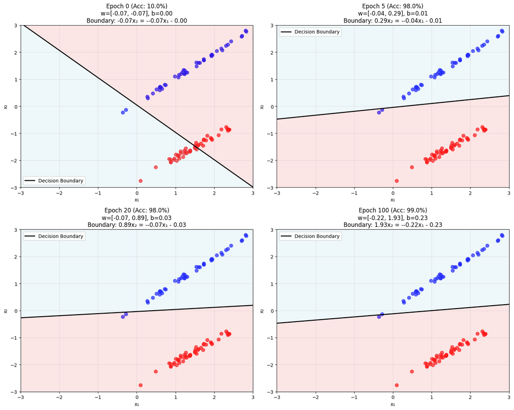

```
=== Decision Boundary Evolution Analysis ===
Final parameters:
Weights: [-0.225, 1.925]
Bias: 0.229
Final accuracy: 99.0%

Decision boundary equation: -0.225x₁ + 1.925x₂ + 0.229 = 0
Line form: x₂ = 0.117x₁ + -0.119

Weight vector magnitude: 1.938
Weight vector direction (unit): [-0.116, 0.993]
Weight vector angle: 96.7°
Distance from origin to boundary: 0.118
```

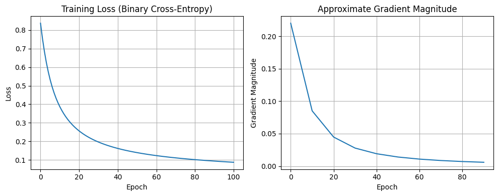

```
=== Generalization to Higher Dimensions ===
In 2D: Decision boundary is a LINE
In 3D: Decision boundary is a PLANE
In nD: Decision boundary is a HYPERPLANE
Formula: w₁x₁ + w₂x₂ + ... + wₙxₙ + b = 0

This single neuron concept generalizes to:
• Multi-class: Multiple hyperplanes (one-vs-rest)
• Non-linear: Multiple neurons create CONVEX HULLS
• Deep networks: Combinations of convex regions
```

```python
import numpy as np
import matplotlib.pyplot as plt
import torch
import torch.nn as nn
import torch.optim as optim
from sklearn.datasets import make_classification

# Set random seeds for reproducibility
torch.manual_seed(42)
np.random.seed(42)

class ClassificationNeuron(nn.Module):
    """Single neuron for binary classification with decision boundary analysis."""

    def __init__(self):
        super(ClassificationNeuron, self).__init__()
        self.linear = nn.Linear(2, 1)  # 2D input -> 1 output

        # Initialize with small random weights
        nn.init.normal_(self.linear.weight, 0, 0.1)
        nn.init.zeros_(self.linear.bias)

    def forward(self, x):
        z = self.linear(x)
        return torch.sigmoid(z)

    def get_decision_boundary(self, x_range=(-3, 3)):
        """
        Get decision boundary line points.
        Decision boundary: w1*x1 + w2*x2 + b = 0
        Rearranged: x2 = -(w1/w2)*x1 - (b/w2)
        """
        w1, w2 = self.linear.weight.data[0]
        b = self.linear.bias.data[0]

        x1_points = np.linspace(x_range[0], x_range[1], 100)

        # Avoid division by zero
        if abs(w2) < 1e-6:
            # Vertical line: x1 = -b/w1
            x1_line = -b/w1 if abs(w1) > 1e-6 else 0
            return np.full_like(x1_points, x1_line), x1_points
        else:
            x2_points = -(w1/w2) * x1_points - (b/w2)
            return x1_points, x2_points

# Generate linearly separable 2D dataset
print("=== Decision Boundary Learning Demo ===")
X_np, y_np = make_classification(n_samples=100, n_features=2, n_redundant=0,
                                n_informative=2, n_clusters_per_class=1,
                                class_sep=1.5, random_state=42)

# Convert to PyTorch tensors
X = torch.FloatTensor(X_np)
y = torch.FloatTensor(y_np).unsqueeze(1)

print(f"Dataset shape: {X.shape}")
print(f"Class distribution: {torch.bincount(y.squeeze().long())}")

# Create and train the neuron
neuron = ClassificationNeuron()
criterion = nn.BCELoss()
optimizer = optim.SGD(neuron.parameters(), lr=0.1)

# Training parameters
epochs = [0, 5, 20, 100]  # Epochs at which to visualize
losses = []
boundary_evolution = []

# Store initial state
w_init = neuron.linear.weight.data.clone()
b_init = neuron.linear.bias.data.clone()
boundary_evolution.append((w_init.clone(), b_init.clone()))

print(f"\nInitial parameters:")
print(f"Weights: [{w_init[0,0]:.3f}, {w_init[0,1]:.3f}]")
print(f"Bias: {b_init[0]:.3f}")

# Training loop with visualization
fig, axes = plt.subplots(2, 2, figsize=(15, 12))
axes = axes.flatten()

epoch_idx = 0
current_epoch = 0

for epoch in range(max(epochs) + 1):
    # Forward pass
    outputs = neuron(X)
    loss = criterion(outputs, y)

    # Backward pass
    optimizer.zero_grad()
    loss.backward()
    optimizer.step()

    losses.append(loss.item())

    # Store parameters at key epochs
    if epoch in epochs:
        w_current = neuron.linear.weight.data.clone()
        b_current = neuron.linear.bias.data.clone()
        boundary_evolution.append((w_current.clone(), b_current.clone()))

        # Plot current state
        ax = axes[epoch_idx]

        # Plot data points
        colors = ['red' if label == 0 else 'blue' for label in y_np]
        ax.scatter(X_np[:, 0], X_np[:, 1], c=colors, alpha=0.7, s=50)

        # Plot decision boundary
        w1, w2 = w_current[0]
        b = b_current[0]

        # Create decision boundary line
        try:
            if abs(w2) > 1e-6:  # Non-vertical line
                x1_boundary = np.linspace(-3, 3, 100)
                x2_boundary = -(w1/w2) * x1_boundary - (b/w2)

                # Plot the decision boundary line
                ax.plot(x1_boundary, x2_boundary, 'black', linewidth=2,
                       label='Decision Boundary', linestyle='-')
            else:  # Vertical line
                if abs(w1) > 1e-6:
                    x1_boundary_val = -b/w1
                    ax.axvline(x=x1_boundary_val, color='black', linewidth=2,
                             label='Decision Boundary', linestyle='-')
        except Exception as e:
            # Fallback: draw a simple line through the center
            x1_center = np.linspace(-3, 3, 100)
            if abs(w2) > 1e-6:
                x2_center = -(w1/w2) * x1_center - (b/w2)
                ax.plot(x1_center, x2_center, 'black', linewidth=2,
                       label='Decision Boundary', linestyle='-', alpha=0.7)

        # Add background coloring for regions
        x1_mesh, x2_mesh = np.meshgrid(np.linspace(-3, 3, 50), np.linspace(-3, 3, 50))
        z_mesh = w1 * x1_mesh + w2 * x2_mesh + b
        ax.contourf(x1_mesh, x2_mesh, z_mesh, levels=[-1000, 0, 1000],
                   colors=['lightcoral', 'lightblue'], alpha=0.2)

        # Calculate accuracy
        with torch.no_grad():
            predictions = (outputs > 0.5).float()
            accuracy = (predictions == y).float().mean()

        # Format title with parameters
        w1, w2 = w_current[0]
        b = b_current[0]
        ax.set_title(f'Epoch {epoch} (Acc: {accuracy:.1%})\n'
                    f'w=[{w1:.2f}, {w2:.2f}], b={b:.2f}\n'
                    f'Boundary: {w2:.2f}x₂ = -{w1:.2f}x₁ - {b:.2f}')

        ax.set_xlabel('x₁')
        ax.set_ylabel('x₂')
        ax.grid(True, alpha=0.3)
        ax.set_xlim(-3, 3)
        ax.set_ylim(-3, 3)
        ax.legend()

        epoch_idx += 1

plt.tight_layout()
plt.show()

# Final analysis
print(f"\n=== Decision Boundary Evolution Analysis ===")
final_w = neuron.linear.weight.data[0]
final_b = neuron.linear.bias.data[0]

print(f"Final parameters:")
print(f"Weights: [{final_w[0]:.3f}, {final_w[1]:.3f}]")
print(f"Bias: {final_b:.3f}")

# Final accuracy
with torch.no_grad():
    final_outputs = neuron(X)
    final_predictions = (final_outputs > 0.5).float()
    final_accuracy = (final_predictions == y).float().mean()
    print(f"Final accuracy: {final_accuracy:.1%}")

# Decision boundary analysis
print(f"\nDecision boundary equation: {final_w[0]:.3f}x₁ + {final_w[1]:.3f}x₂ + {final_b:.3f} = 0")
if abs(final_w[1]) > 1e-6:
    slope = -final_w[0] / final_w[1]
    intercept = -final_b / final_w[1]
    print(f"Line form: x₂ = {slope:.3f}x₁ + {intercept:.3f}")

# Weight vector interpretation
weight_magnitude = torch.norm(final_w)
weight_direction = final_w / weight_magnitude
print(f"\nWeight vector magnitude: {weight_magnitude:.3f}")
print(f"Weight vector direction (unit): [{weight_direction[0]:.3f}, {weight_direction[1]:.3f}]")
print(f"Weight vector angle: {torch.atan2(weight_direction[1], weight_direction[0]) * 180 / np.pi:.1f}°")

# Distance from origin to decision boundary
distance_to_origin = abs(final_b) / weight_magnitude
print(f"Distance from origin to boundary: {distance_to_origin:.3f}")

# Plot training loss
plt.figure(figsize=(10, 4))
plt.subplot(1, 2, 1)
plt.plot(losses)
plt.title('Training Loss (Binary Cross-Entropy)')
plt.xlabel('Epoch')
plt.ylabel('Loss')
plt.grid(True)

# Plot gradient magnitude over training
plt.subplot(1, 2, 2)
# Compute gradient magnitudes manually for demonstration
gradient_mags = []
for i in range(0, len(losses), 10):  # Sample every 10 epochs
    # Reset to state at epoch i and compute gradients
    with torch.no_grad():
        # Approximate gradient magnitude from loss change
        if i > 0:
            grad_approx = abs(losses[i] - losses[i-1]) * 10  # Scaled for visibility
            gradient_mags.append(grad_approx)

plt.plot(range(0, len(losses), 10)[:len(gradient_mags)], gradient_mags)
plt.title('Approximate Gradient Magnitude')
plt.xlabel('Epoch')
plt.ylabel('Gradient Magnitude')
plt.grid(True)

plt.tight_layout()
plt.show()

print(f"\n=== Generalization to Higher Dimensions ===")
print("In 2D: Decision boundary is a LINE")
print("In 3D: Decision boundary is a PLANE")
print("In nD: Decision boundary is a HYPERPLANE")
print("Formula: w₁x₁ + w₂x₂ + ... + wₙxₙ + b = 0")
print("\nThis single neuron concept generalizes to:")
print("• Multi-class: Multiple hyperplanes (one-vs-rest)")
print("• Non-linear: Multiple neurons create CONVEX HULLS")
print("• Deep networks: Combinations of convex regions")
```

### Generalization to Higher Dimensions

The 2D decision boundary concept is fundamental to understanding neural networks in higher dimensions:

#### Linear Separability

A single neuron can only learn **linearly separable** patterns:

- **2D**: Points separated by a line
- **3D**: Points separated by a plane
- **nD**: Points separated by a hyperplane

The hyperplane equation in $n$-dimensional space: $$\sum_{i=1}^{n} w_i x_i + b = 0$$

#### Geometric Properties

1. **Normal vector**: $\mathbf{w} = [w_1, w_2, \ldots, w_n]^T$ is perpendicular to the hyperplane
2. **Distance to origin**: $\frac{|b|}{||\mathbf{w}||}$
3. **Classification**: Based on which side of hyperplane points fall

#### Limitations and Extensions

**Single Neuron Limitations:**

- Can only create **one** hyperplane
- Cannot solve **XOR** problem (non-linearly separable)
- Limited to **convex** decision regions

**Multi-Neuron Extensions:**

- **Multiple neurons** → Multiple hyperplanes → **Convex hull** regions
- **Hidden layers** → Combinations of convex regions → **Complex boundaries**
- **Deep networks** → Arbitrary decision boundaries

This progression from line → hyperplane → convex hull → complex regions is the mathematical foundation of how neural networks increase in representational power.

## Summary

The artificial neuron is a fundamental component that:

### Core Functionality

1. **Receives** multiple inputs $(x_1, x_2, \ldots, x_n)$
2. **Weights** each input with learnable parameters $(w_1, w_2, \ldots, w_n)$
3. **Adds** a bias term $b$
4. **Applies** an activation function $f$
5. **Produces** a single output $y$

### Decision Boundary Capability

- **Creates linear decision boundaries** (hyperplanes) in input space
- **Separates binary classes** using the equation $\mathbf{w}^T\mathbf{x} + b = 0$
- **Learns through gradient descent** by rotating and translating the boundary
- **Generalizes from 2D lines** to higher-dimensional hyperplanes

### Mathematical Foundation

- **Linear separability**: Can only solve linearly separable problems
- **Geometric interpretation**: Weight vector is perpendicular to decision boundary
- **Learning dynamics**: Gradients adjust parameters to minimize classification error
- **Scaling pathway**: Single neuron → multiple neurons → convex hulls → complex boundaries

### Key Properties

- **Learnable parameters**: Weights and bias adjusted during training
- **Differentiable**: Enables gradient-based optimization
- **Geometrically interpretable**: Clear relationship between parameters and decision boundary
- **Fundamental building block**: Basis for multilayer perceptrons, CNNs, and transformers

This component serves as the mathematical and conceptual foundation for understanding how neural networks learn to partition input spaces and make predictions.

## Next Steps in Neural Network Components

### Building on the Foundation

The artificial neuron is the fundamental building block, but neural networks become powerful through:

1. **Multiple Neurons**: Combining many neurons in layers
2. **Deep Architectures**: Stacking layers to create complex functions
3. **Specialized Components**: Different types of layers and connections

### Key Components to Explore

- **Activation Functions**: Deep dive into the non-linear transformations that make learning possible
- **Layer Types**: Dense/Linear, Convolutional, Recurrent layers
- **Optimization**: How networks learn through backpropagation and gradient descent
- **Regularization**: Techniques to prevent overfitting and improve generalization

### From Single Neuron to Deep Networks

```
Single Neuron → Multi-layer Perceptron → Deep Neural Networks → Specialized Architectures
     ↓                    ↓                        ↓                       ↓
Linear Separation    Non-linear Boundaries    Universal Approximation    Task-specific Solutions
```

The journey from understanding a single neuron to mastering deep learning involves progressively building complexity while maintaining mathematical rigor and practical understanding.

**Continue your learning journey**:

- Explore Activation Functions to understand the $f$ function in detail
- Study multi-layered architectures to see how neurons combine
- Practice implementing and training neural networks

**Happy Learning!** 🧠⚡